# VA Calibration

openVA Team

2025-09-19

# Introduction

# Getting Started

We begin by attaching the **openVA** package, which attaches and prints the versions of the core packages and, if installed, the optional packages. **vacalibration** is among the optional packages and must be installed alongside **openVA**, e.g., `install.packages(c("openVA", "vacalibration"))`

```r
library(openVA)
```

```
## ────────────────────── Attaching packages for openVA 1.2.0 ─────────────────────
## ── Optional packages (require manual installation if not attached) ─────────────
```

In the example code to follow we use the example data set “NeonatesVA5” that contains 200 (simulated) neonate VAs and is included in **openVA**. These data are simulated from the 2016 WHO VA instrument, and can be loaded with:

```r
data(NeonatesVA5)
dim(NeonatesVA5)
```

```
## [1] 200 354
```

# Cause Assignment (uncalibrated)

We start by assigning CoDs to the example data set using the InSilicoVA and InterVA5 algorithms. The simulated data are based on the 2016 WHO VA instrument, which we specify by passing “WHO2016” to the `data.type` parameter.

```r
fit_insilicova <- codeVA(NeonatesVA5, data.type = "WHO2016")
fit_interva <- codeVA(NeonatesVA5, model = "InterVA", version = "5",
                      HIV = "l", Malaria = "l", write = FALSE)
# omitting messages about the data checks, record processing, and posterior sampling...
```

*Note:* In the example code for InterVA5 (shown above), we set the `write` parameter to “FALSE” which will prevent the function from producing the log file with information about VA records excluded from the analysis (due to missing data) and the data consistency checks. In real analyses it is recommended to set `write` to “TRUE” (and provide the path to the `directory` parameter, which is where the log file will be written).

# VA Calibration

Before calibrating the results, we must prepare the fitted objects into the format expected by the `vacalibration()` function. Specifically, we need to prepare a list of data frames that include two columns: (1) the ID for the individual deaths, and (2) the CoD assigned by the algorithm. **openVA** includes a helper function `prepCalibration()` that performs this step for us:

```r
insilicova_prep <- prepCalibration(fit_insilicova)
interva_prep <- prepCalibration(fit_interva)
```

As we will see below, the `vacalibration()` tool can combine results across algorithms to produce an ensemble of the cause-specific mortality fractions (CSMFs). To obtain the ensemble estimate, we simply pass multiple fitted objects from `codeVA()` to the `prepCalibration()` function as follows:

```r
two_fits <- prepCalibration(fit_insilicova, fit_interva)
```

The results can now be passed to the `vacalibration()` function. In the following example, we do this separately for each algorithm as well as for the combined list needed to produce the ensemble estimate of the calibrated CSMF. To contain the length of this vignette, we do not include the diagnostic and summary plots of the results and we omit the output detailing the posterior sampling.

```r
calib_insilicova = vacalibration::vacalibration(va_data = insilicova_prep,
                                                age_group = "neonate",
                                                country = "Mozambique",
                                                plot_it = FALSE)
calib_interva <- vacalibration::vacalibration(va_data = interva_prep,
                                            age_group = "neonate",
                                            country = "Mozambique",
                                            plot_it = FALSE)
calib_ensemble <- vacalibration::vacalibration(va_data = two_fits,
                                               age_group = "neonate",
                                               country = "Mozambique",
                                               plot_it = FALSE)
# omitting messages about posterior sampling...
```

# Results

## tabular summaries

**openVA** implements some basic S3 methods to make your VA data analysis experience a bit more enjoyable. For example, the basic print method for a `vacalibration` fitted object provides a quick summary of the posterior sampling, the algorithm(s) included in the calibration, and the input data.

```r
calib_insilicova
## vacalibration fitted object:
## 10000 iterations performed, with first 5000 iterations discarded.
##  5000 iterations saved after thinning
##
## Results for: insilicova (calibrated):  81 neonate deaths
```

More useful is the well-known `summary()` method that (in the VA space) prints out a summary of the posterior sampling, the number of VA records processed by the algorithm, and the ordered CSMF (and credible intervals where applicable). Users have the option to specify the number of causes to include in the summary through the `top` parameter. The seasoned VA analysts may notice different CoDs than what InSilicoVA assigns (i.e., those causes from the WHO VA cause list). `vacalibration()` employs a mapping to a “broad cause of death” list via the `vacalibration::cause_map()` function (as described in the [vacalibration vignette](https://CRAN.R-project.org/package=vacalibration/vignettes/intro_to_vacalibration.html#broad-cause-of-death) ).

```r
summary(calib_insilicova, top = 5)
## VA Calibration
## 10000 iterations performed, with first 5000 iterations discarded.
##  5000 iterations saved after thinning
##
## insilicova (calibrated)
## 81 neonate deaths
## Top 5 CSMFs:
##
##   cause                   mean   lower  upper
## 1 sepsis_meningitis_inf   0.4804 0.3431 0.6358
## 2 pneumonia               0.2211 0.0766 0.3605
## 3 other                   0.1235 0.1235 0.1235
## 4 prematurity             0.0718 0.0048 0.1670
## 5 congenital_malformation 0.0617 0.0617 0.0617
```

It is also worth noting that `summary()` returns a list of objects that can be useful for further analysis; one example is ordered CSMF returned as a data frame (as shown below).

```r
summ_calib_interva <- summary(calib_interva)
names(summ_calib_interva)
```

```
##  [1] "nBurn"               "nIterations"         "nMCMC"
##  [4] "nThin"               "age_group"           "algorithms"
##  [7] "n"                   "show_top"            "ensemble"
## [10] "ensemble_algorithms" "uncalibrated"        "pcalib_postsumm"
## [13] "interva"
```

```r
is.data.frame(summ_calib_interva$interva)
```

```
## [1] TRUE
```

```r
summ_calib_interva$interva
```

```
##                     cause   mean  lower  upper
## 1                    ipre 0.7453 0.6403 0.8433
## 2 congenital_malformation 0.1207 0.0506 0.2059
## 3   sepsis_meningitis_inf 0.0632 0.0197 0.1264
## 4               pneumonia 0.0364 0.0047 0.0890
## 5             prematurity 0.0213 0.0009 0.0649
```

When working with a `vacalibration` fitted object involving results from multiple algorithms – e.g., an ensemble calibration of the CSMF – it is possible to limit the summarized results to a subset by passing the algorithm name or “ensemble” to the `algorithm` parameter. (The default behavior is to print out summaries for all inputs, including the “ensemble” if applicable.)

```r
summary(calib_ensemble, algorithm = "ensemble")
## VA Calibration
## 10000 iterations performed, with first 5000 iterations discarded.
##  5000 iterations saved after thinning
##
## Ensemble of: insilicova interva
## Top 5 CSMFs:
##
##   cause                   mean   lower  upper
## 1 sepsis_meningitis_inf   0.6132 0.3355 0.7660
## 2 ipre                    0.1467 0.0220 0.3979
## 3 congenital_malformation 0.0922 0.0507 0.1439
## 4 other                   0.0701 0.0701 0.0701
## 5 pneumonia               0.0535 0.0085 0.1305
```

## plots

Visual displays of VA results are available in **openVA** through the `plotVA()` function. There are several options to control the layout and type of plot. The default is a horizontal plot of error bars:

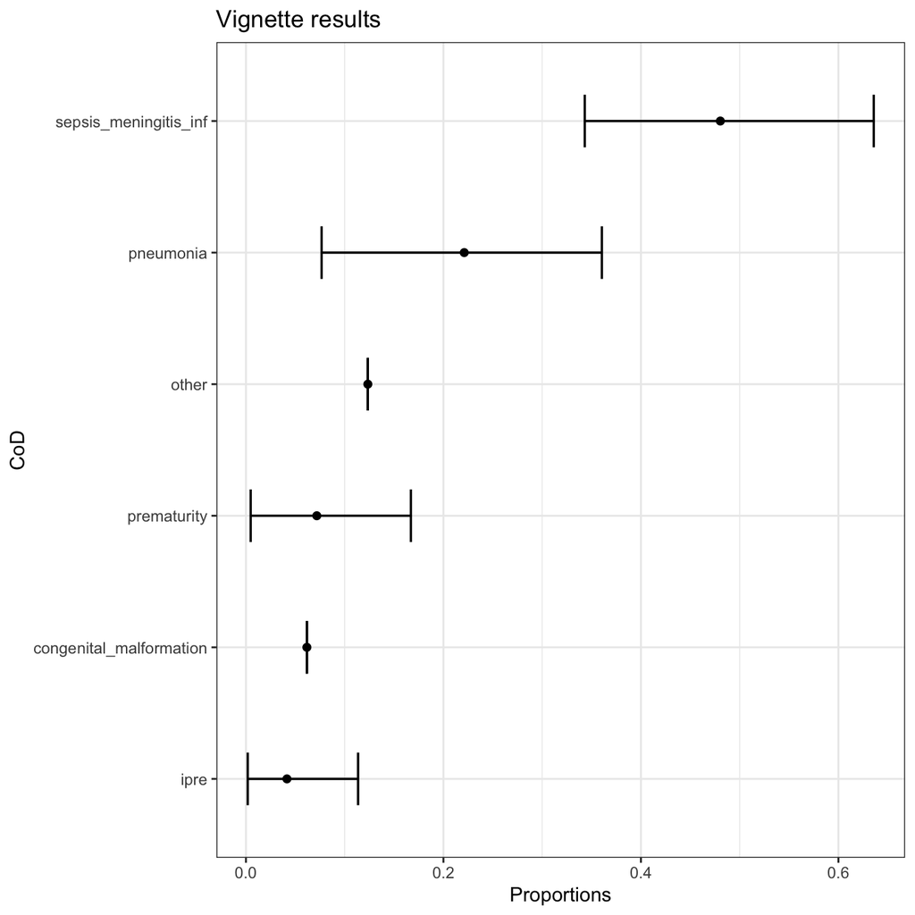

```r
plotVA(calib_insilicova, title = "Vignette results",
       xlab = "CoD", ylab = "Proportions")
```

`vacalibrated` fitted objects include the uncalibrated results as well. A comparison can be made by setting the `uncalibrated` parameter to “TRUE”. This option is illustrated below in the form of a basic bar graph with the horizontal option turned off – i.e., `horiz = FALSE`:

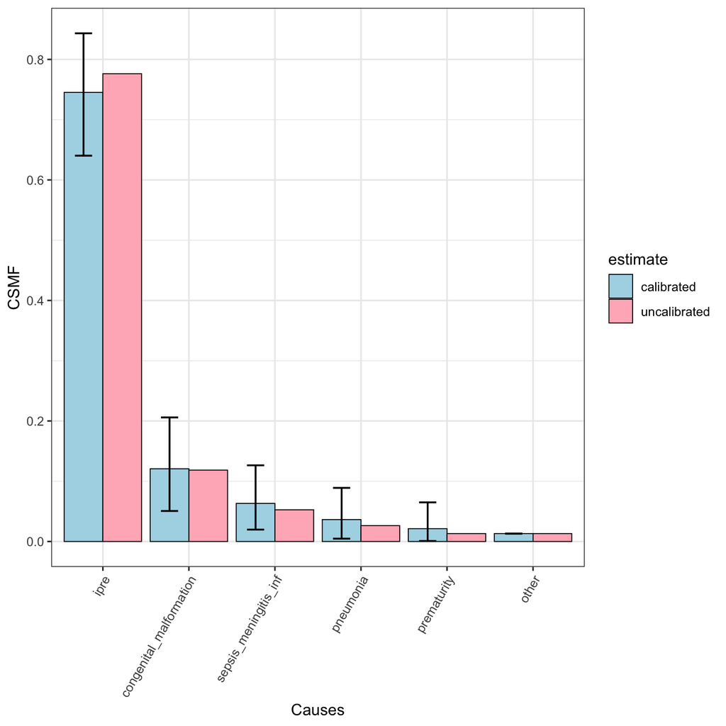

```r
plotVA(calib_interva, type = "bar", uncalibrated = TRUE, horiz = FALSE)
```

When working with a `vacalibrated` object that includes results from multiple algorithms, like our ensemble example, it is worth noting that the `plotVA()` function returns a list of `ggplot` objects, one for each algorithm and for the ensemble if applicable. (This is also the case if the `vacalibrated` object only includes calibrated restuls for a single object – which is why the algorithm name or “ensemble” is printed after the call to `plotVA()` – so it is possible to make further customizations to the plot.)

```r
ensemble_plots <- plotVA(calib_ensemble)
names(ensemble_plots)
```

```
## [1] "ensemble"   "insilicova" "interva"
```

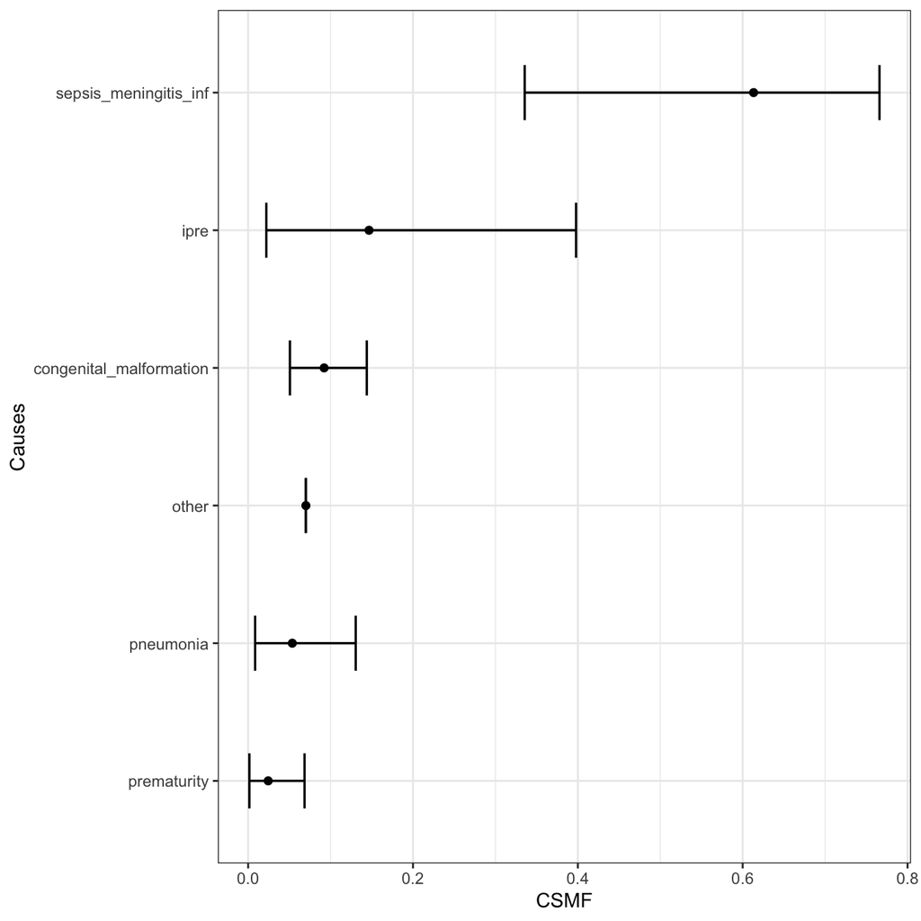

```r
ensemble_plots$ensemble
```

For our last example, we illustrate the “compare” type of plot that combine all of the calibrated results onto a single plot:

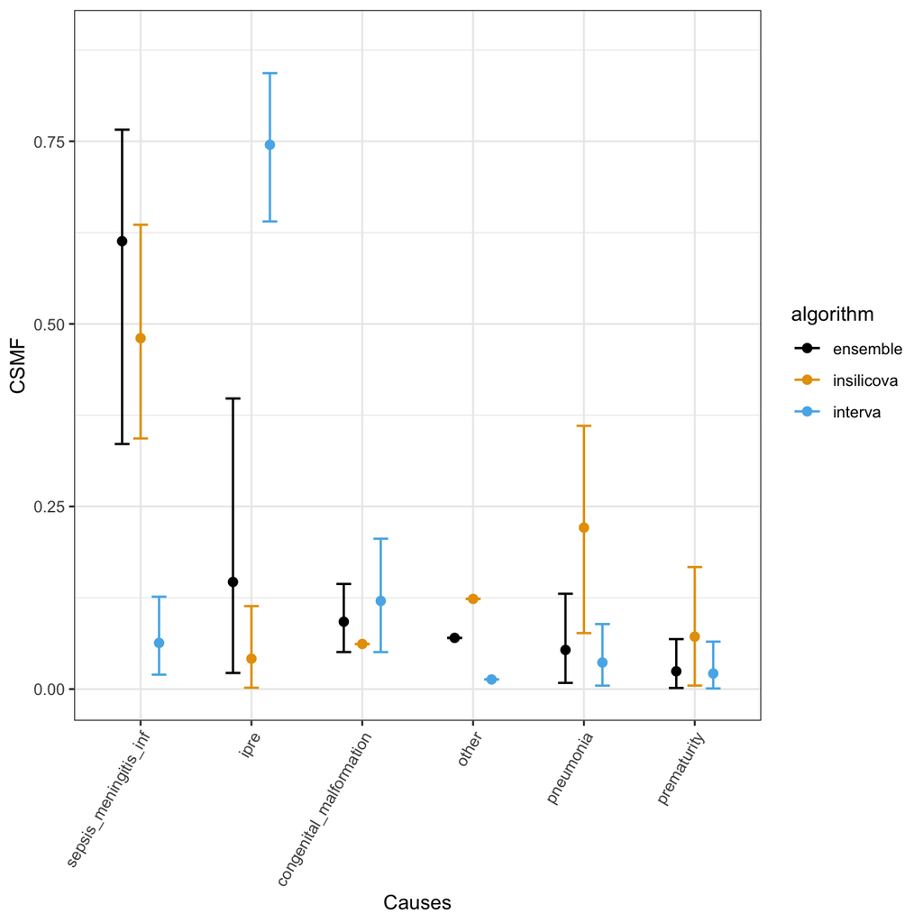

```r
plotVA(calib_ensemble, type = "compare", horiz = FALSE)
```

# Conclusion

The typical analysis utilizing the computer-coded verbal autopsy method involves transforming (hopefully cleaned) VA data into a particular format and then employing an algorithm to assign causes of death and produce an estimated CSMF. In this vignette we have skipped the first step, but would like to point users to the Python package [pycrossva](https://github.com/verbal-autopsy-software/pyCrossVA) for more information. **vacalibration** provides a valuable extension to the analysis of neonate and child deaths that improves the accuracy of the population CSMF and can also leverage results from multiple algorithms. The openVA Team has made some steps to integrate the **vacalibration** package into **openVA**, but we welcome further suggestions to improve the interoperability of this growing VA ecosystem of software. To do so, please submit suggests (and bug reports) via the [GitHub issue tracker for the openVA package](https://github.com/verbal-autopsy-software/openVA/issues).

# References

Pramanik, Sandipan, Scott Zeger, Dianna Blau, and Abhirup Datta. 2025. “Modeling structure and country-specific heterogeneity in misclassification matrices of verbal autopsy-based cause of death classifiers,” *The Annals of Applied Statistics*: 19(2), 1214-1239.